# Economics Assignment 1 v3 - Estimating Demand Curve

**Changes from version 2**

- Clustering no longer considered - hueristic groupings for demand is being used, whereby elasticity is being calculated for equal number of transactions done over time. This allows us to understand how the demand function needs to adjust for across these groups of values

> Assumptions: 1. The sales data has tickets sold to multiple locations across multiple classes of tickets. 2. The mean price calculated is a function of the passenger manifesto as well (i.e. a booking can include a combination of adults + children + elderly etc.)

# 1 Reading Data & Libraries

```
   ggplot2      dplyr        AER ggcorrplot      caret    mltools data.table
      TRUE       TRUE       TRUE       TRUE       TRUE       TRUE       TRUE
View of dataset:
```

|  | dtd | num_bookings | mean_net_ticket_price | inv |
| --- | --- | --- | --- | --- |
| 1 | 0 | 1 | 107.29 | 1 |
| 2 | 0 | 1 | 147.34 | 1 |
| 3 | 0 | 1 | 106.47 | 1 |
| 4 | 0 | 1 | 106.47 | 1 |
| 5 | 0 | 1 | 106.17 | 1 |
| 6 | 0 | 1 | 145.61 | 1 |

# 2 Data Exploration & Manipulation

```
Null values present in data:
                  dtd          num_bookings mean_net_ticket_price                   inv
                    0                     0                     0                     0
Days on which no booking is made:
 [1] 254 282 312 337 338 339 340 344 345 346 347 348 350 355 356 357 358 359 360
[1] "Total number of bookings since day 360: 12313"
[1] "Number of new ticket-types observed in data: 1444"
New Dataset:
```

|  | dtd_new | num_bookings | mean_net_ticket_price | inv | DuplicateFlag | Cumulative_booking | Dummy_month | Dummy_quarter |
| --- | --- | --- | --- | --- | --- | --- | --- | --- |
| 1 | 0 | 1 | 107.29 | 1 | 1 | 2 | 1 | 1 |
| 2 | 0 | 1 | 147.34 | 1 | 1 | 2 | 1 | 1 |
| 3 | 0 | 1 | 106.47 | 1 | 1 | 2 | 1 | 1 |
| 4 | 0 | 1 | 106.47 | 1 | 1 | 2 | 1 | 1 |
| 5 | 0 | 1 | 106.17 | 1 | 1 | 2 | 1 | 1 |
| 6 | 0 | 1 | 145.61 | 1 | 1 | 2 | 1 | 1 |

# 3 Equations and Correlations

## 3.1 Observing correlations

```
                      dtd_new num_bookings mean_net_ticket_price   inv
dtd_new                  1.00         0.12                   0.1 -0.39
num_bookings             0.12         1.00                  -0.1  0.19
mean_net_ticket_price    0.10        -0.10                   1.0 -0.20
inv                     -0.39         0.19                  -0.2  1.00
Readable Matrix Visualisation
```

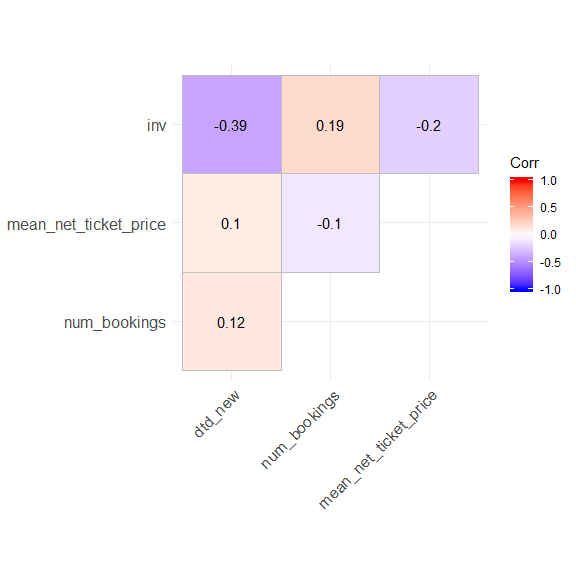

> Structural Equations:

Demand = B0 + B1(Mean Price)

Supply = A0 + A1(Mean Price) + A2(Cumulative #)

**Reduced Equation**

Price* = C0 + C1(Cumulative#)

## 3.2 OLS

```
Call:
lm(formula = log(num_bookings) ~ log(mean_net_ticket_price),
    data = Cleaned_Data, na.omit = T)

Residuals:
    Min      1Q  Median      3Q     Max
-0.6404 -0.4451 -0.3375  0.3126  2.8123

Coefficients:
                            Estimate Std. Error t value Pr(>|t|)
(Intercept)                 0.737069   0.030581   24.10   <2e-16 ***
log(mean_net_ticket_price) -0.059255   0.005786  -10.24   <2e-16 ***
---
Signif. codes:  0 ‘***’ 0.001 ‘**’ 0.01 ‘*’ 0.05 ‘.’ 0.1 ‘ ’ 1

Residual standard error: 0.5649 on 6525 degrees of freedom
  (19 observations deleted due to missingness)
Multiple R-squared:  0.01582,   Adjusted R-squared:  0.01567
F-statistic: 104.9 on 1 and 6525 DF,  p-value: < 2.2e-16
```

## 3.3 2SLS

```
Call:
ivreg(formula = log(num_bookings) ~ log(mean_net_ticket_price) |
    inv, data = Cleaned_Data, na.omit = T)

Residuals:
     Min       1Q   Median       3Q      Max
-1.85556 -0.55621 -0.06392  0.43538  2.96180

Coefficients:
                           Estimate Std. Error t value Pr(>|t|)
(Intercept)                 2.51634    0.17396   14.46   <2e-16 ***
log(mean_net_ticket_price) -0.40509    0.03377  -12.00   <2e-16 ***

Diagnostic tests:
                  df1  df2 statistic p-value
Weak instruments    1 6525     310.6  <2e-16 ***
Wu-Hausman          1 6524     174.5  <2e-16 ***
Sargan              0   NA        NA      NA
---
Signif. codes:  0 ‘***’ 0.001 ‘**’ 0.01 ‘*’ 0.05 ‘.’ 0.1 ‘ ’ 1

Residual standard error: 0.7027 on 6525 degrees of freedom
Multiple R-Squared: -0.523, Adjusted R-squared: -0.5232
Wald test: 143.9 on 1 and 6525 DF,  p-value: < 2.2e-16
```

Although we see some correlation between inv (cumulative sales) & net price of ticket, introducing it as IV has substantially changed the estimate for price (**-0.405 vs -0.06**). Still relatively inelastic, prices appear to have more impact on demand than observed before.

## 3.4 Heuristic grouping of demand

While our model above estimates the true value of price-estimate over the entire 1 year period; it is also true that there are various other external factors that impact demand/supply. Fare elasticities to areas, different geographies, ticket classes, quality of service & reliability are only some of them. A key component of the demand, though, are certain factors that change over time. **Elasticities of other modes of transport, prices of gasoline/fuel, car ownership & ease of drive, weather** are factors that influence a person’s decision to purchase a train ticket as they approach the travel date. (Supply can also be adjusted to match demand at different price by changing quota of seats within trains! But we restrict our analysis to demand function)

Based on the latter factors listed above (**in bold**) (some of which could be unpredictable), one could hypothesize that the demand/supply and price relationships adjust multiple times to achieve equilibrium over the duration of a period, **as these factors cause the demand curve to shift**. As pointed above, they become increasingly prominent in influencing the purchase of a train ticket & consequently the demand function at a given time.

In an open market, this shift in demand curve would cause the supply curve to adjust such that the equilibrium price remains constant. But because of limited supply of tickets available, implying a restricted movement of the supply curve, the prices adjust upward/downward. Using the underlying mechanic defined here and the influence of external factors specified above, we hope to capture the true estimate of price across multiple time-frames.

### 3.4.1 Choosing time-frames

The time-frames have been chosen in such a way that they reflect equal sales of ticket across them. This was done to ensure that there is no bias of sales across a time period of consideration. Consequently, the below buckets were obtained:

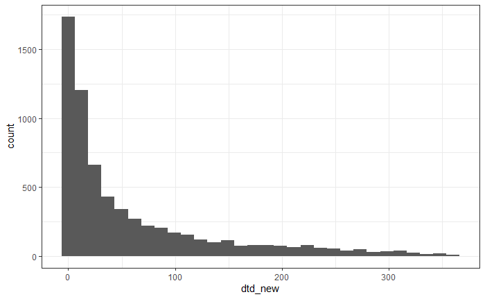

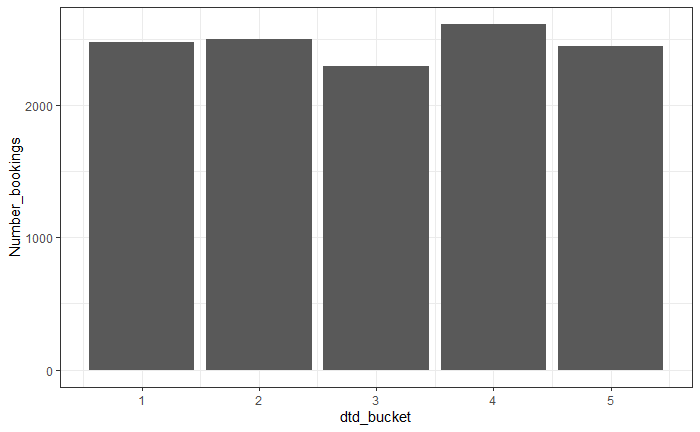

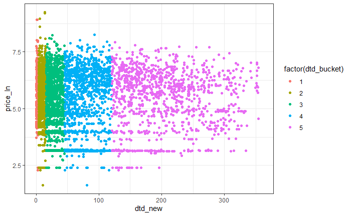

```
Call:
lm(formula = log(num_bookings) ~ price_ln, data = d1)

Residuals:
    Min      1Q  Median      3Q     Max
-0.6228 -0.5545 -0.1244  0.4569  2.3754

Coefficients:
            Estimate Std. Error t value Pr(>|t|)
(Intercept)  1.31115    0.10362   12.65  < 2e-16 ***
price_ln    -0.16158    0.02088   -7.74 2.13e-14 ***
---
Signif. codes:  0 ‘***’ 0.001 ‘**’ 0.01 ‘*’ 0.05 ‘.’ 0.1 ‘ ’ 1

Residual standard error: 0.5995 on 1173 degrees of freedom
Multiple R-squared:  0.0486,    Adjusted R-squared:  0.04778
F-statistic: 59.91 on 1 and 1173 DF,  p-value: 2.129e-14

Output for 2SLS: ================================================================

Call:
ivreg(formula = log(num_bookings) ~ price_ln | inv, data = d1,
    na.omit = T)

Residuals:
      Min        1Q    Median        3Q       Max
-2.074040 -0.701843  0.001772  0.504206  3.388823

Coefficients:
            Estimate Std. Error t value Pr(>|t|)
(Intercept)  4.73837    0.48404   9.789   <2e-16 ***
price_ln    -0.86211    0.09881  -8.725   <2e-16 ***

Diagnostic tests:
                  df1  df2 statistic p-value
Weak instruments    1 1173     112.5  <2e-16 ***
Wu-Hausman          1 1172     118.8  <2e-16 ***
Sargan              0   NA        NA      NA
---
Signif. codes:  0 ‘***’ 0.001 ‘**’ 0.01 ‘*’ 0.05 ‘.’ 0.1 ‘ ’ 1

Residual standard error: 0.8394 on 1173 degrees of freedom
Multiple R-Squared: -0.8648,    Adjusted R-squared: -0.8664
Wald test: 76.12 on 1 and 1173 DF,  p-value: < 2.2e-16
```

```
Call:
lm(formula = log(num_bookings) ~ price_ln, data = d)

Residuals:
    Min      1Q  Median      3Q     Max
-0.5280 -0.3465 -0.2661  0.3280  2.6279

Coefficients:
            Estimate Std. Error t value Pr(>|t|)
(Intercept)  0.62542    0.06092  10.266  < 2e-16 ***
price_ln    -0.05972    0.01167  -5.118 3.47e-07 ***
---
Signif. codes:  0 ‘***’ 0.001 ‘**’ 0.01 ‘*’ 0.05 ‘.’ 0.1 ‘ ’ 1

Residual standard error: 0.4864 on 1550 degrees of freedom
Multiple R-squared:  0.01662,   Adjusted R-squared:  0.01599
F-statistic:  26.2 on 1 and 1550 DF,  p-value: 3.469e-07

Output for 2SLS: ================================================================

Call:
ivreg(formula = log(num_bookings) ~ price_ln | inv, data = d,
    na.omit = T)

Residuals:
     Min       1Q   Median       3Q      Max
-1.76763 -0.55289  0.02188  0.34571  2.34286

Coefficients:
            Estimate Std. Error t value Pr(>|t|)
(Intercept)  2.44589    0.30414   8.042 1.74e-15 ***
price_ln    -0.41581    0.05941  -6.999 3.83e-12 ***

Diagnostic tests:
                  df1  df2 statistic p-value
Weak instruments    1 1550    102.02 < 2e-16 ***
Wu-Hausman          1 1549     63.77 2.7e-15 ***
Sargan              0   NA        NA      NA
---
Signif. codes:  0 ‘***’ 0.001 ‘**’ 0.01 ‘*’ 0.05 ‘.’ 0.1 ‘ ’ 1

Residual standard error: 0.6154 on 1550 degrees of freedom
Multiple R-Squared: -0.5742,    Adjusted R-squared: -0.5752
Wald test: 48.99 on 1 and 1550 DF,  p-value: 3.826e-12
```

```
Call:
lm(formula = log(num_bookings) ~ price_ln, data = d)

Residuals:
    Min      1Q  Median      3Q     Max
-0.4676 -0.3574 -0.2832  0.3379  2.5107

Coefficients:
            Estimate Std. Error t value Pr(>|t|)
(Intercept)  0.57798    0.06080   9.507  < 2e-16 ***
price_ln    -0.04614    0.01144  -4.035 5.77e-05 ***
---
Signif. codes:  0 ‘***’ 0.001 ‘**’ 0.01 ‘*’ 0.05 ‘.’ 0.1 ‘ ’ 1

Residual standard error: 0.5161 on 1366 degrees of freedom
Multiple R-squared:  0.01178,   Adjusted R-squared:  0.01105
F-statistic: 16.28 on 1 and 1366 DF,  p-value: 5.77e-05

Output for 2SLS: ================================================================

Call:
ivreg(formula = log(num_bookings) ~ price_ln | inv, data = d,
    na.omit = T)

Residuals:
    Min      1Q  Median      3Q     Max
-1.8668 -0.6063  0.0247  0.5464  2.9457

Coefficients:
            Estimate Std. Error t value Pr(>|t|)
(Intercept)   3.1805     0.4616   6.891 8.44e-12 ***
price_ln     -0.5491     0.0891  -6.163 9.40e-10 ***

Diagnostic tests:
                  df1  df2 statistic  p-value
Weak instruments    1 1366     56.62 9.56e-14 ***
Wu-Hausman          1 1365     85.12  < 2e-16 ***
Sargan              0   NA        NA       NA
---
Signif. codes:  0 ‘***’ 0.001 ‘**’ 0.01 ‘*’ 0.05 ‘.’ 0.1 ‘ ’ 1

Residual standard error: 0.8023 on 1366 degrees of freedom
Multiple R-Squared: -1.388, Adjusted R-squared: -1.389
Wald test: 37.98 on 1 and 1366 DF,  p-value: 9.396e-10
```

```
Call:
lm(formula = log(num_bookings) ~ price_ln, data = d)

Residuals:
    Min      1Q  Median      3Q     Max
-0.5901 -0.4427 -0.3661  0.2970  2.4725

Coefficients:
            Estimate Std. Error t value Pr(>|t|)
(Intercept)  0.70143    0.05552  12.633  < 2e-16 ***
price_ln    -0.04651    0.01038  -4.479 8.15e-06 ***
---
Signif. codes:  0 ‘***’ 0.001 ‘**’ 0.01 ‘*’ 0.05 ‘.’ 0.1 ‘ ’ 1

Residual standard error: 0.5746 on 1332 degrees of freedom
Multiple R-squared:  0.01484,   Adjusted R-squared:  0.0141
F-statistic: 20.06 on 1 and 1332 DF,  p-value: 8.147e-06

Output for 2SLS: ================================================================

Call:
ivreg(formula = log(num_bookings) ~ price_ln | inv, data = d,
    na.omit = T)

Residuals:
    Min      1Q  Median      3Q     Max
-2.1676 -0.9519  0.1582  0.7383  3.2725

Coefficients:
            Estimate Std. Error t value Pr(>|t|)
(Intercept)   3.6587     0.6579   5.561 3.23e-08 ***
price_ln     -0.6233     0.1282  -4.862 1.30e-06 ***

Diagnostic tests:
                  df1  df2 statistic  p-value
Weak instruments    1 1332     29.63 6.21e-08 ***
Wu-Hausman          1 1331     72.29  < 2e-16 ***
Sargan              0   NA        NA       NA
---
Signif. codes:  0 ‘***’ 0.001 ‘**’ 0.01 ‘*’ 0.05 ‘.’ 0.1 ‘ ’ 1

Residual standard error: 1.046 on 1332 degrees of freedom
Multiple R-Squared: -2.267, Adjusted R-squared: -2.269
Wald test: 23.64 on 1 and 1332 DF,  p-value: 1.298e-06
```

```
Call:
lm(formula = log(num_bookings) ~ price_ln, data = d)

Residuals:
    Min      1Q  Median      3Q     Max
-0.7786 -0.5363  0.0258  0.3722  2.6531

Coefficients:
            Estimate Std. Error t value Pr(>|t|)
(Intercept)  0.93858    0.08337  11.258  < 2e-16 ***
price_ln    -0.06685    0.01493  -4.478 8.32e-06 ***
---
Signif. codes:  0 ‘***’ 0.001 ‘**’ 0.01 ‘*’ 0.05 ‘.’ 0.1 ‘ ’ 1

Residual standard error: 0.6141 on 1096 degrees of freedom
  (19 observations deleted due to missingness)
Multiple R-squared:  0.01797,   Adjusted R-squared:  0.01707
F-statistic: 20.05 on 1 and 1096 DF,  p-value: 8.319e-06

Output for 2SLS: ================================================================

Call:
ivreg(formula = log(num_bookings) ~ price_ln | inv, data = d,
    na.omit = T)

Residuals:
    Min      1Q  Median      3Q     Max
-3.8374 -1.4040 -0.2417  1.3271  5.0654

Coefficients:
            Estimate Std. Error t value Pr(>|t|)
(Intercept)  -6.6149     5.2651  -1.256    0.209
price_ln      1.3204     0.9669   1.366    0.172

Diagnostic tests:
                  df1  df2 statistic  p-value
Weak instruments    1 1096     2.325    0.128
Wu-Hausman          1 1095    18.609 1.75e-05 ***
Sargan              0   NA        NA       NA
---
Signif. codes:  0 ‘***’ 0.001 ‘**’ 0.01 ‘*’ 0.05 ‘.’ 0.1 ‘ ’ 1

Residual standard error: 1.83 on 1096 degrees of freedom
Multiple R-Squared: -7.72,  Adjusted R-squared: -7.727
Wald test: 1.865 on 1 and 1096 DF,  p-value: 0.1724
```